# Publish R Markdown to WordPress Blog? Yes You Can!

JY

2021-12-23

This post is based on an R Markdown file published directly to WordPress.com - and you can do it, too! It was made possible by the great work of others, shared in the following **highly recommended** resources:

1. [RWordPress pkg](https://github.com/duncantl/RWordPress) by Duncan Temple Lang (2012) - there was a helpful vignette but can’t find it any longer
2. [Publish blog posts from R + knitr to WordPress](https://yihui.org/knitr/demo/wordpress/) by Yihui Xie (2013)
3. [How to Publish with R Markdown in WordPress](http://3.14a.ch/archives/2015/03/08/how-to-publish-with-r-markdown-in-wordpress/) by 3.14a (2015)
4. [Blog Posting from R Markdown to WordPress](http://sites.tufts.edu/emotiononthebrain/2017/08/12/blog-posting-from-r-markdown-to-wordpress/) by Heather Urry (2017)
5. [How to Publish a Blog Post on WordPress using RMarkdown](https://tobiasdienlin.com/2019/03/08/how-to-publish-a-blog-post-on-wordpress-using-rmarkdown/) by Tobias Deinlin (2019)

So nothing new here, other than recap of the above and confirmation that although the code behind this was produced in 2012-13, it **still works as of August, 2021**. :)

Note that since my blog is on [WordPress.com](https://wordpress.com) hosted site, I’m focusing on that environment. Resources above cover variations to the process required for a self-hosted [WordPress.org](https://wordpress.org/) site.

RMarkdown file available in this Github repo: https://github.com/jyuill/r-markdown-wordpress

## Steps

Summary of steps to be taken to publish R Markdown on WordPress.

1. Install packages needed.
2. Do some R Markdown - example case below.
3. Publish to WordPress - by running separate code using RWordPress pkg.

Key thing to note here is that you are not directly uploading the html file that your RMarkdown produces. Rather you are knitting the .Rmd file in a way that results in a blog post being published to your Wordpress blog (can be public or draft).

## 1. Install Packages

The key to the process is the **RWordPress** package, supported by the XMLRPC package, both of which you can get using the code below (along with knitr pkg):

```r
## References
## http://tabvizexplorer.com/how-to-upload-r-markdown-directly-to-wordpress/

## Get required packages
if (!require('knitr')) {install.packages("knitr")}
if (!require('devtools')) {install.packages("devtools")}
if (!require('RWordPress')) {devtools::install_github(c("duncantl/XMLRPC", "duncantl/RWordPress"))}
```

As others have warned, the **RWordPress package is no longer being maintained** - so use at your own risk.

The other key is the **‘knit2wp’** function in the knitr package, hence the need to install that if not already installed, as well.

## 2. Produce R Markdown

As mentioned, this blog post in entirely created with RMarkdown. For demonstrating data analysis features, I’m walking through an example below based on my personal collection of [Vancouver weather data](https://github.com/jyuill/proj-r-van-weather/raw/master/output/van-weather.csv) ;).

The idea here is to demonstrate some typical Markdown capabilities that you may want to have in your blog post:

### Annual Temperature Data

To explore the data across the period covered, summarize by year. (*mouseover the code block and drag to scroll horizontally*)

```r
## summarize annual temperature
annual_summary <- dataset %>% filter(Year<max(dataset$Year)) %>% ## remove most recent yr, since incomplete data
  group_by(Year) %>% summarize(max_temp=max(Max.Temp, na.rm=TRUE),
                               min_temp=min(Min.Temp, na.rm=TRUE),
                               mean_daily_temp=mean(Mean.Temp, na.rm=TRUE),
                               annual_precip=sum(Total.Precip, na.rm=TRUE))
```

Check out the data structure: (*mouseover to scroll horizontally*)

```
## tibble [51 × 5] (S3: tbl_df/tbl/data.frame)
##  $ Year           : num [1:51] 1970 1971 1972 1973 1974 ...
##  $ max_temp       : num [1:51] 30.6 29.4 27.2 28.9 27.2 27.8 25 30.5 30.1 28.7 ...
##  $ min_temp       : num [1:51] -7.2 -12.8 -11.1 -10.6 -8.3 -7.2 -6.7 -8.1 -13.5 -11.2 ...
##  $ mean_daily_temp: num [1:51] 9.43 9.09 9.07 9.59 9.91 ...
##  $ annual_precip  : num [1:51] 875 1335 1244 1000 1248 ...
```

Summary of the data:

```
##       Year         max_temp       min_temp      mean_daily_temp annual_precip
##  Min.   :1970   Min.   :25.0   Min.   :-15.20   Min.   : 8.92   Min.   : 810
##  1st Qu.:1982   1st Qu.:27.9   1st Qu.:-11.25   1st Qu.: 9.88   1st Qu.:1029
##  Median :1995   Median :28.8   Median : -9.10   Median :10.27   Median :1207
##  Mean   :1995   Mean   :28.8   Mean   : -9.42   Mean   :10.30   Mean   :1174
##  3rd Qu.:2008   3rd Qu.:29.6   3rd Qu.: -7.70   3rd Qu.:10.80   3rd Qu.:1296
##  Max.   :2020   Max.   :34.4   Max.   : -3.10   Max.   :11.45   Max.   :1522
```

#### Annual temperature patterns across the period:

(*Name the code chunk with a meaningful name for the plot as this will be used to save the image file for uploading to Wordpress*)

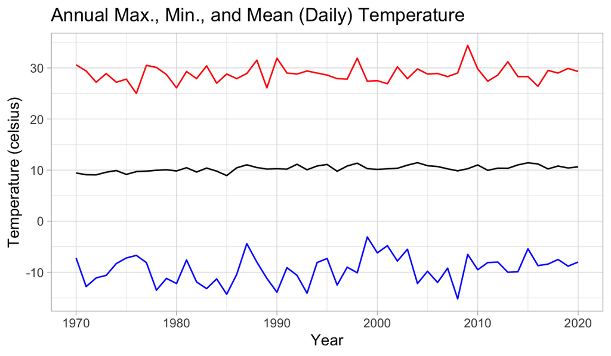

```r
## visualize
tplot1 <- annual_summary %>%
  ggplot(aes(x=Year))+
  geom_line(aes(y=mean_daily_temp), color='black')+
  geom_line(aes(y=max_temp), color='red')+
  geom_line(aes(y=min_temp), color='blue')+
  labs(title="Annual Max., Min., and Mean (Daily) Temperature",
       y='Temperature (celsius)')+
  theme_light()

tplot1
```

I’m no climatologist, and this is very imprecise data exploration, but appears there might be a slight but gradual upward drift in temperatures over this relatively short period.

### Annual Precipitation

Vancouver is famous for it’s rainfall. How much rain has Vancouver received each year over the period covered? 1970 to 2020 (*years shown are based on dynamic reference to data source*)

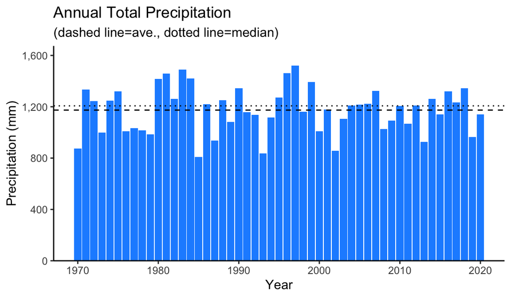

That’s right…Vancouver frequently gets **over 1,000 mm - 1 meter - of rain** in a year!

- average for last 50 years:1174.153 per year
- median over last 50 years: 1207 per year

(*figures based on automatic calculations at run-time*)

### Monthly Precipitation Patterns

Surely the rain is not steady all year long? What are the monthly patterns?

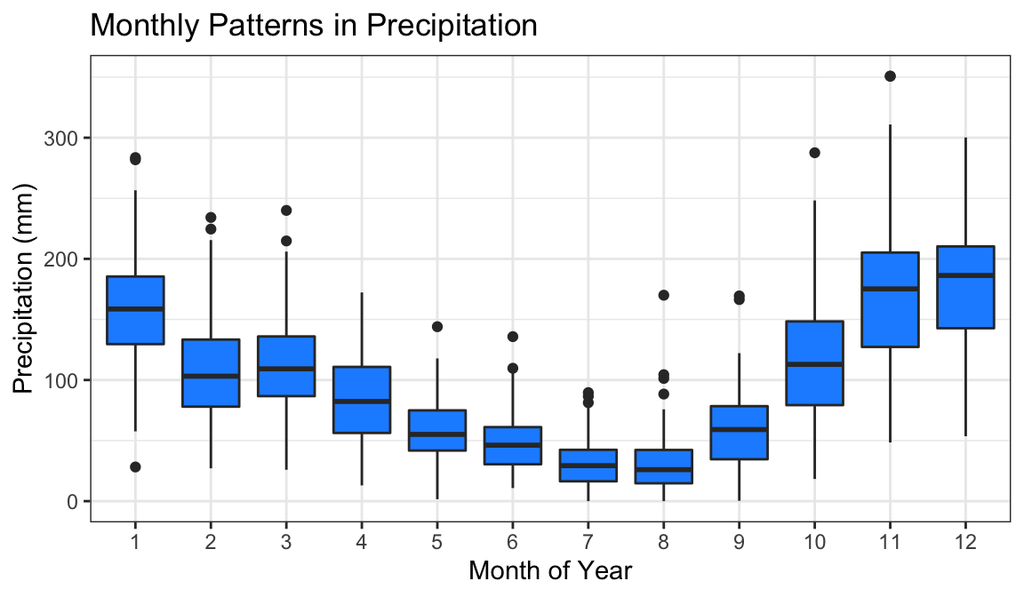

Dry in summer, wet in winter - especially November, December and, to lesser extent, January. By May, we’re *usually* safely out of the rainy season. Until October rolls around and the rains set in again.

## 3. Publish to WordPress

Once your R Markdown file is polished to your liking, you just need to run some simple code to send it to WordPress:

```
1. load libraries
library(RWordPress)
library(knitr)

2. set credentials
options(WordpressLogin= c(<username>='<pwd>'),
       WordpressURL=paste0('https://<blog name>.wordpress.com/xmlrpc.php'))

3. setup to upload plots
 - saves image files named after code chunks in WordPress Media section by date
opts_knit$set(upload.fun=function(file){library(RWordPress);uploadFile(file)$url;})

4. knit to WP
knit2wp("<markdown file name>",        ## markdown file to publish
        title = "<post title>",        ## title for the post in WordPress
        publish = FALSE,               ## FALSE to add as draft; TRUE to go direct to publish
        action = "newPost",            ## for new post; alternatives: "editPost", "newPage"
        #postid                        ## needed with editPost - get from WP interface
        shortcode= FALSE,              ## optional - affects how code is shown; default FALSE
        categories= c('R Markdown'))   ## set categories, if desired

5. Upload featured image / post thumbnail: option: wp_post_thumbnail=postThumbnail$id
postThumbnail <- RWordPress::uploadFile("figure/<image file>",overwrite = TRUE)
```

You can set up a standard file and substitute values for markdown file and title as needed. Of course, you want to **keep it private since you have password in there** - add to .gitignore if you have a public Github repo.

## Limitations

Or at least things I haven’t figured out how to do yet:

1. **No interactive plotly plots**: render fine in R Markdown but don’t make it to WP. Probably because plots are published based on static image files.
2. **Internal anchor links**: tricky to set internal anchor links. Using {#anchor-name} beside heading works in R Markdown, but shows up as printed text in WP; using html like h2 tag with id=“anchor-name” works in WP and R Markdown knit but doesn’t show up as heading in document outline - which can be a pain for long docs.
3. **glimpse** function: for some reason, using the glimpse() function seems to throw an error. (caused me several hrs of trouble-shooting)

If I find solutions to these - or uncover more limitations - I’ll pass along updates.

## Alternatives

At the end of the day, this works but not ideal and may not provide the flexibility everyone is looking for. There is also the element of risk inherent in the fact that the process depends on R packages that are no longer maintained.

I was keen to get this to work because I have a legacy WordPress blog that I want to build on, including accessing the features of the world’s most popular content management system, and I want to extend it with work done in my primary environment - RStudio / RMarkdown.

Obviously, there are lots of other options, and warnings during process suggest you may want to check out **blogdown** for building blogs/websites with R Markdown.

So we’ll see where this goes, but in meantime, hopefully some helpful tips here for others determined to make R Markdown work in WordPress.